# Exercises - Day 9

Elisa

18 July 2019

# Exercise 1

Load the data set “repeated”. Under the presence and absence of snails (treatment “Mollusc”) and with insects being sprayed with a pesticide or not (treatment “Insect”) grass biomass (variable “Grass”) was measured over time (1 - 6 weeks, “Time”) in six blocks (“Block”). How does the treatments affect grass biomass?

Using the knowledge gained so far: - build a model to answer this question. - Fit it and validate it. - Use an appropriate test for the hypothesis that spraying insects and absence of snails affect grass biomass over time.

### Load and inspect the data

```r
grass <- read.delim("repeated.txt")
head(grass)
```

```
##   Block Time  Insect Mollusc    Grass
## 1     A    1 Sprayed Present 100.0991
## 2     A    2 Sprayed Present 104.9327
## 3     A    3 Sprayed Present 108.3628
## 4     A    4 Sprayed Present 109.5858
## 5     A    5 Sprayed Present 113.3127
## 6     A    6 Sprayed Present 118.5464
```

```r
str(grass)
```

```
## 'data.frame':    120 obs. of  5 variables:
##  $ Block  : Factor w/ 5 levels "A","B","C","D",..: 1 1 1 1 1 1 1 1 1 1 ...
##  $ Time   : int  1 2 3 4 5 6 1 2 3 4 ...
##  $ Insect : Factor w/ 2 levels "Sprayed","Unsprayed": 1 1 1 1 1 1 1 1 1 1 ...
##  $ Mollusc: Factor w/ 2 levels "Absent","Present": 2 2 2 2 2 2 1 1 1 1 ...
##  $ Grass  : num  100 105 108 110 113 ...
```

We do not neet to convert any data to factor, the categorical variables are already coded as factors. But it is important not to forget this at the begining.

Make a simple plot to see how the data look like. This is also really important not to work in the darkness…

```r
library(dplyr)
```

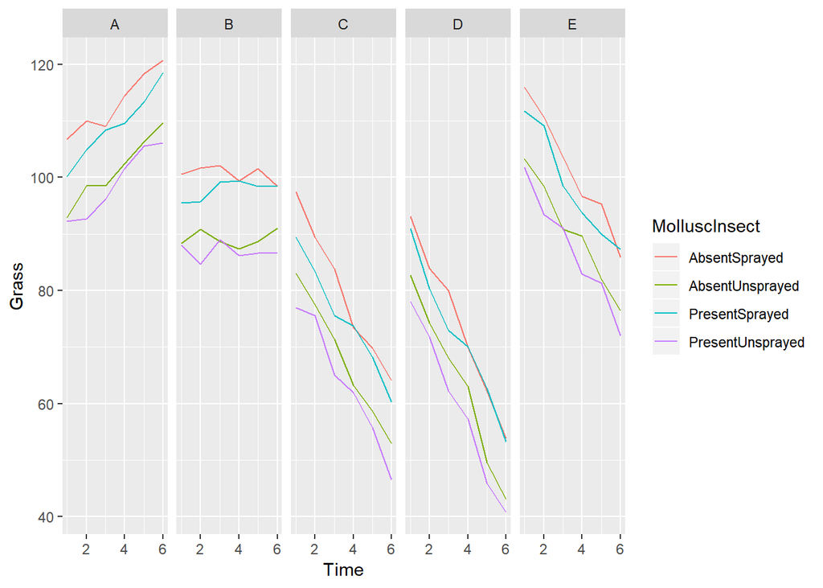

```r
library(tidyr)
library(ggplot2)
grass$MolluscInsect <- paste0(grass$Mollusc, grass$Insect)

grass %>% ggplot(aes(x=Time, y=Grass, group=MolluscInsect, color=MolluscInsect))+
  geom_line() +
  facet_grid(.~Block)
```

Nice, we have some more information about what is happening. There is a clear correllation os block as expected. Absent sprayed seem to be higher in all the blocks, followed by present-sprayed, Absent unspryed and present unsprayed. We also see that the slopes aare quite different per block (A,B,C,D,E), so we should deffinetly add random intercept and slope.

#### Fit the model

```r
library(lme4)

m0 <- lmer(Grass ~ Insect*Mollusc*Time + (Insect*Mollusc*Time|Block), data=grass)
summary(m0)
```

```
## Linear mixed model fit by REML ['lmerMod']
## Formula: Grass ~ Insect * Mollusc * Time + (Insect * Mollusc * Time |
##     Block)
##    Data: grass
##
## REML criterion at convergence: 496.7
##
## Scaled residuals:
##      Min       1Q   Median       3Q      Max
## -1.83920 -0.66673 -0.03282  0.67641  2.29341
##
## Random effects:
##  Groups   Name                                Variance Std.Dev. Corr
##  Block    (Intercept)                         87.79060 9.3697
##           InsectUnsprayed                      0.72980 0.8543   -0.32
##           MolluscPresent                       1.24550 1.1160    0.75
##           Time                                21.36213 4.6219   -0.28
##           InsectUnsprayed:MolluscPresent       1.15980 1.0769   -0.35
##           InsectUnsprayed:Time                 0.02644 0.1626    0.57
##           MolluscPresent:Time                  0.05045 0.2246   -0.82
##           InsectUnsprayed:MolluscPresent:Time  0.01945 0.1395    0.60
##  Residual                                      2.28618 1.5120
##
##
##
##   0.21
##  -0.25 -0.09
##  -0.67 -0.56  0.77
##  -0.92  0.00 -0.09  0.33
##   0.29 -0.84 -0.25  0.06 -0.38
##   0.01  0.80  0.45 -0.06 -0.01 -0.90
##
## Number of obs: 120, groups:  Block, 5
##
## Fixed effects:
##                                     Estimate Std. Error t value
## (Intercept)                         106.2128     4.2373  25.066
## InsectUnsprayed                     -12.6292     0.9688 -13.036
## MolluscPresent                       -6.2028     1.0206  -6.078
## Time                                 -3.5695     2.0733  -1.722
## InsectUnsprayed:MolluscPresent        3.1388     1.3480   2.329
## InsectUnsprayed:Time                  0.3660     0.2399   1.526
## MolluscPresent:Time                   0.8312     0.2497   3.329
## InsectUnsprayed:MolluscPresent:Time  -0.8654     0.3292  -2.628
##
## Correlation of Fixed Effects:
##             (Intr) InsctU MllscP Time   InU:MP InsU:T MllP:T
## InsctUnspry -0.221
## MollscPrsnt  0.272  0.442
## Time        -0.282 -0.053 -0.002
## InsctUns:MP -0.055 -0.701 -0.674  0.243
## InsctUnsp:T  0.260 -0.897 -0.373 -0.080  0.602
## MllscPrsn:T -0.241 -0.332 -0.883 -0.153  0.553  0.390
## InsctU:MP:T  0.047  0.574  0.619  0.123 -0.828 -0.662 -0.704
## convergence code: 1
## Model failed to converge with max|grad| = 0.232872 (tol = 0.002, component 1)
## maxfun < 10 * length(par)^2 is not recommended.
```

```r
m1 <- lmer(Grass ~ Mollusc*Insect*Time + (Time|Block), data=grass)
summary(m1)
```

```
## Linear mixed model fit by REML ['lmerMod']
## Formula: Grass ~ Mollusc * Insect * Time + (Time | Block)
##    Data: grass
##
## REML criterion at convergence: 503.2
##
## Scaled residuals:
##      Min       1Q   Median       3Q      Max
## -1.81548 -0.70820  0.01367  0.73086  2.35659
##
## Random effects:
##  Groups   Name        Variance Std.Dev. Corr
##  Block    (Intercept) 77.793   8.820
##           Time        21.029   4.586    -0.23
##  Residual              2.486   1.577
## Number of obs: 120, groups:  Block, 5
##
## Fixed effects:
##                                     Estimate Std. Error t value
## (Intercept)                         106.2128     3.9987  26.562
## MolluscPresent                       -6.2028     0.9283  -6.682
## InsectUnsprayed                     -12.6292     0.9283 -13.604
## Time                                 -3.5695     2.0577  -1.735
## MolluscPresent:InsectUnsprayed        3.1388     1.3129   2.391
## MolluscPresent:Time                   0.8312     0.2384   3.487
## InsectUnsprayed:Time                  0.3660     0.2384   1.535
## MolluscPresent:InsectUnsprayed:Time  -0.8654     0.3371  -2.567
##
## Correlation of Fixed Effects:
##             (Intr) MllscP InsctU Time   MlP:IU MllP:T InsU:T
## MollscPrsnt -0.116
## InsctUnspry -0.116  0.500
## Time        -0.240  0.052  0.052
## MllscPrs:IU  0.082 -0.707 -0.707 -0.037
## MllscPrsn:T  0.104 -0.899 -0.449 -0.058  0.635
## InsctUnsp:T  0.104 -0.449 -0.899 -0.058  0.635  0.500
## MllscP:IU:T -0.074  0.635  0.635  0.041 -0.899 -0.707 -0.707
```

```r
m2 <- lmer(Grass ~ Mollusc*Time + Insect*Time + (Time|Block), data=grass)
summary(m2)
```

```
## Linear mixed model fit by REML ['lmerMod']
## Formula: Grass ~ Mollusc * Time + Insect * Time + (Time | Block)
##    Data: grass
##
## REML criterion at convergence: 510.1
##
## Scaled residuals:
##      Min       1Q   Median       3Q      Max
## -1.86162 -0.81929  0.03453  0.70615  2.35666
##
## Random effects:
##  Groups   Name        Variance Std.Dev. Corr
##  Block    (Intercept) 77.769   8.819
##           Time        21.027   4.586    -0.23
##  Residual              2.595   1.611
## Number of obs: 120, groups:  Block, 5
##
## Fixed effects:
##                       Estimate Std. Error t value
## (Intercept)          105.42811    3.98637  26.447
## MolluscPresent        -4.63343    0.67061  -6.909
## Time                  -3.35315    2.05613  -1.631
## InsectUnsprayed      -11.05975    0.67061 -16.492
## MolluscPresent:Time    0.39856    0.17220   2.315
## Time:InsectUnsprayed  -0.06668    0.17220  -0.387
##
## Correlation of Fixed Effects:
##             (Intr) MllscP Time   InsctU MllP:T
## MollscPrsnt -0.084
## Time        -0.238  0.038
## InsctUnspry -0.084  0.000  0.038
## MllscPrsn:T  0.076 -0.899 -0.042  0.000
## Tm:InsctUns  0.076  0.000 -0.042 -0.899  0.000
```

The first model with maximum random effects does not converge. The seccond, that is more reasonable and accouts for the grouping and random slopes converges and shows no problems. The third is a bit simple in it`s fixed effects. And it could be usefull to test the interaction.

#### Check the assumptions of the model.

Quick remind of which are the assumptions of the MEM:

From Crawly - The R Book

There are five fundamental assumptions of linear mixed-effects models:

- Within-group errors are independent with mean zero and variance $\sigma^2$.
- Within-group errors are independent of the random effects.
- The random effects are normally distributed with mean zero and covariance matrix $\phi$.
- The random effects are independent in different groups.
- The covariance matrix does not depend on the group.

#### The random effects are normally distributed

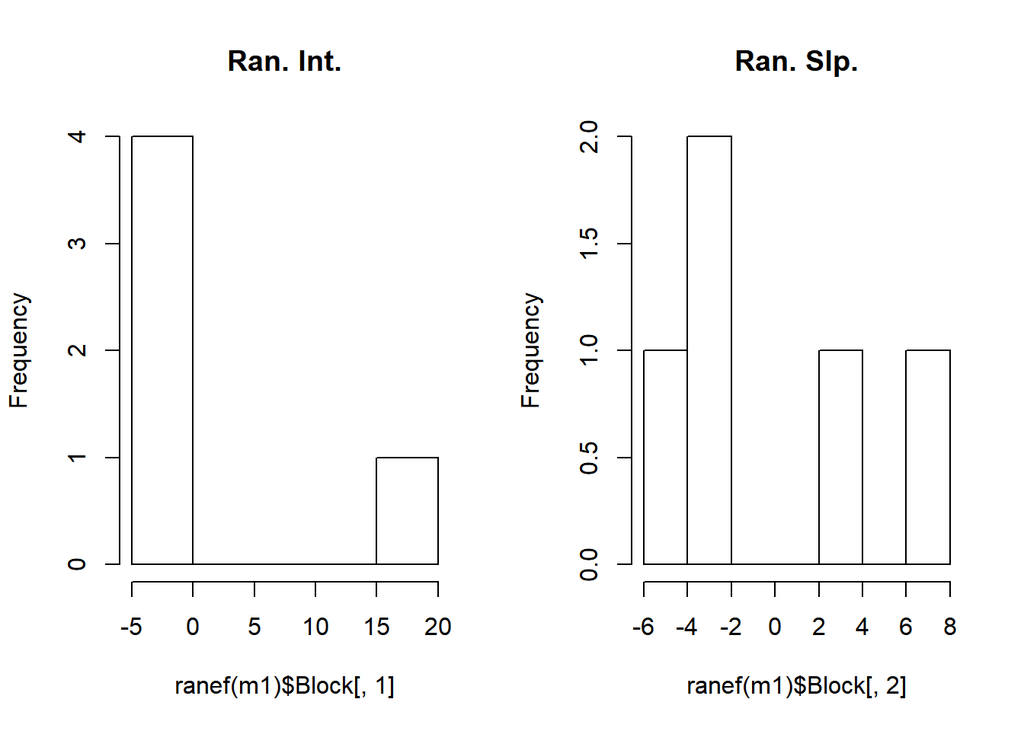

```r
par(mfrow=c(1,2))
hist(ranef(m1)$Block[,1], main="Ran. Int.")
hist(ranef(m1)$Block[,2], main="Ran. Slp.")
```

This plots look really awfull. But it is hard to asess a distribution only with 5 values.

#### Within-group errors are independent with mean zero and variance $\sigma^2$.

This means, the residuals are randomly distributted around the mean. We have to plot the residuals

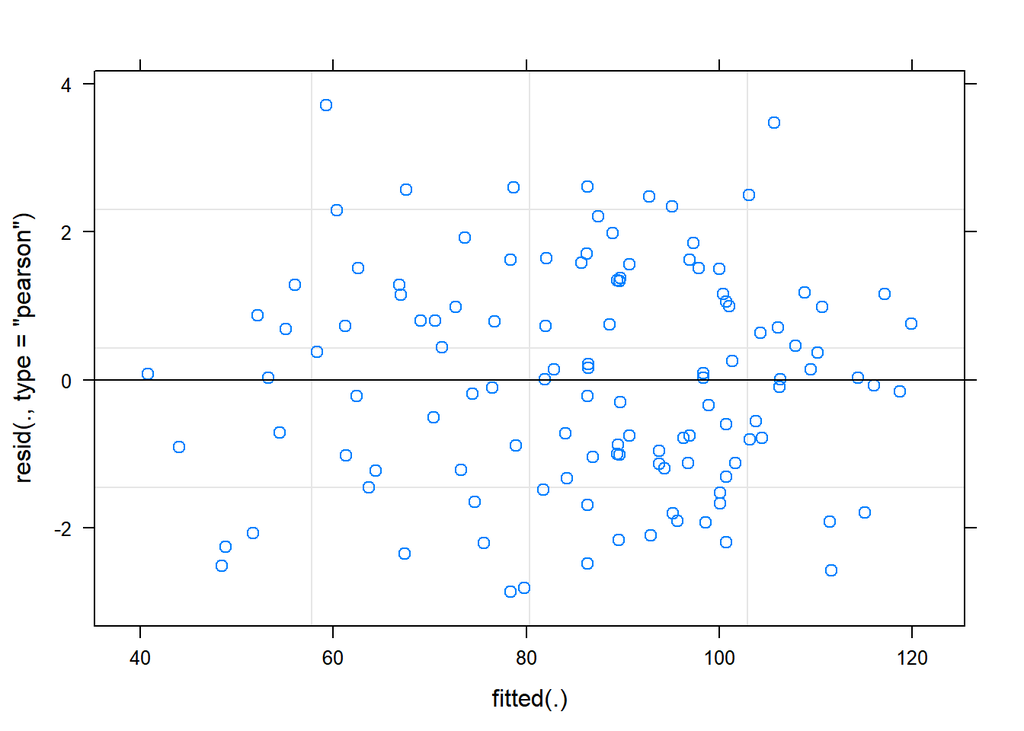

```r
plot(m1)
```

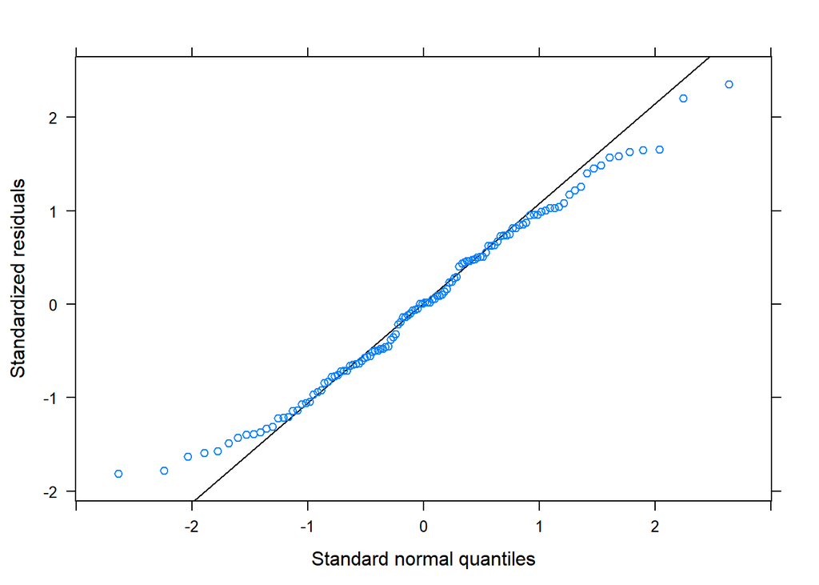

```r
library(lattice)
qqmath(m1)
```

This looks quite good.

#### Within-group errors are independent of the random effects.

This means, for all the random effect groups, the residuals look simmilar, and we check this:

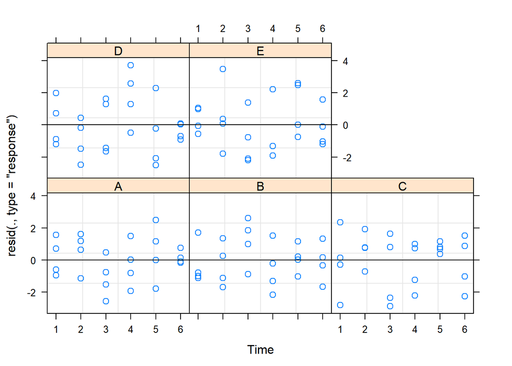

```r
plot(m1, resid(., type = "response") ~ Time | Block, abline = 0) # for each farm
```

This also looks fine. All the blocks have simmilar spred of the residuals. We meet the assumption we were testing. However, in block A and D we see some pattern. But we also have few meassures per block and per date, so it could be just a pattern that we see by chance.

Last check with DAHRMa package

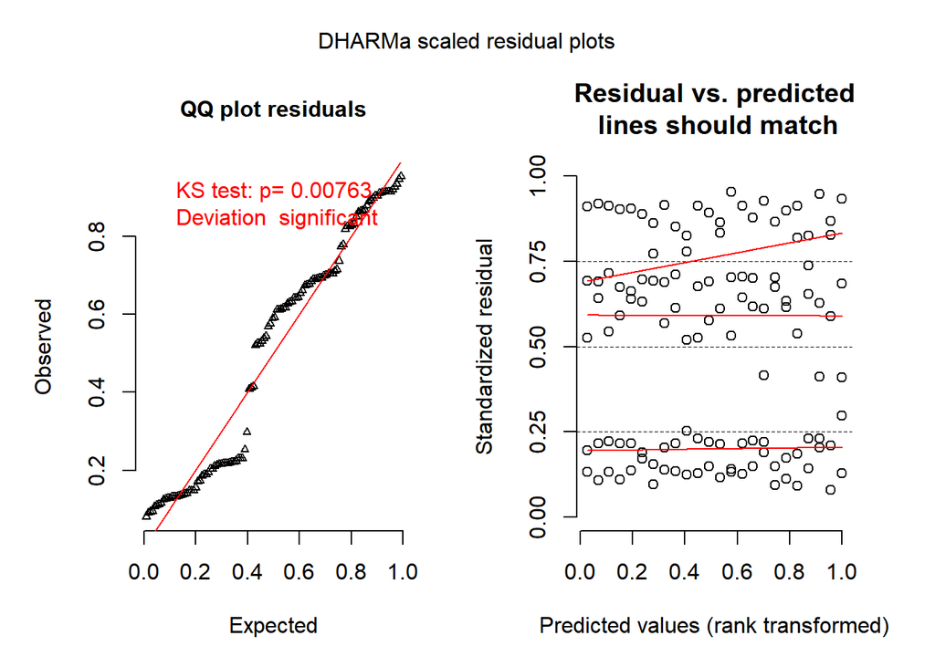

```r
a<- DHARMa::simulateResiduals(m1, n=1000)
plot(a)
```

In this plot the residuals do not seem to be normally distributed…Let’s see the residuals values

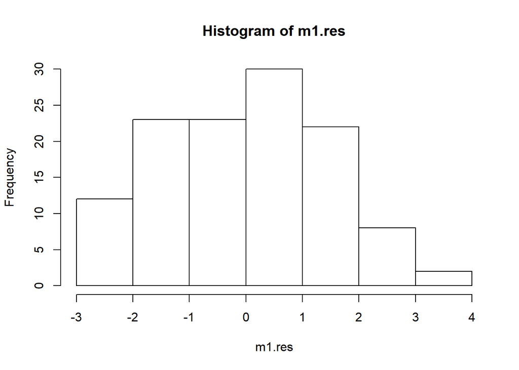

```r
m1.res <- residuals(m1)
hist(m1.res)
```

```r
shapiro.test(m1.res)
```

```
##
##  Shapiro-Wilk normality test
##
## data:  m1.res
## W = 0.98487, p-value = 0.2002
```

This does not look bad…And the test says the resduals are normally distributed

#### The random effects are independent in different groups.

This assumption can not really be checked. It is related to the experimental design and means that there is no sub-grouping of the data. We think that all the measurements inside each group are independent.

### Now let’s start with today task. Hypothesis testing!

We want to ckeck if Mollusc and Treatment affect the grass. We can take this fixed effects out of owr model and see if the model with the predictor performs better than the model without it.

```r
m1 <- update(m1, REML = FALSE)
anova(m1)
```

```
## Analysis of Variance Table
##                     Df Sum Sq Mean Sq   F value
## Mollusc              1  314.6   314.6  133.8613
## Insect               1 3826.1  3826.1 1627.8204
## Time                 1    7.1     7.1    3.0141
## Mollusc:Insect       1    0.1     0.1    0.0386
## Mollusc:Time         1   13.9    13.9    5.9137
## Insect:Time          1    0.4     0.4    0.1655
## Mollusc:Insect:Time  1   16.4    16.4    6.9696
```

Mollusc and insect have very big F values. This means that they are probably significant predictors.

We can also fit simpler models and compare them

```r
m0 <- update(m0, REML=FALSE)
m0.3way <- update(m0, . ~ . - Insect:Mollusc:Time, REML = FALSE)
formula(m0.3way) #some issues dropping interactions
```

```
## Grass ~ Insect + Mollusc + Time + (Insect * Mollusc * Time |
##     Block) + Insect:Mollusc + Insect:Time + Mollusc:Time
```

```r
#m0.3way <- lmer(Grass ~ Insect+Mollusc+Time + (Insect*Mollusc*Time|Block), data=grass, REML=FALSE)
formula(m0.3way)
```

```
## Grass ~ Insect + Mollusc + Time + (Insect * Mollusc * Time |
##     Block) + Insect:Mollusc + Insect:Time + Mollusc:Time
```

The simpler model that converges

```r
m1 <- lmer(Grass ~ Mollusc*Insect*Time + (Time|Block), data=grass)
m1.3way <- update(m1, . ~ . - Insect:Mollusc:Time, REML = FALSE)
#m1.3way <- lmer(Grass ~ Mollusc+Insect+Time + (Time|Block), data=grass)
formula(m1.3way) #some issues dropping interactions
```

```
## Grass ~ Mollusc + Insect + Time + (Time | Block) + Mollusc:Insect +
##     Mollusc:Time + Insect:Time
```

LEt’s compare

```r
anova (m1, m1.3way)
```

```
## Data: grass
## Models:
## m1.3way: Grass ~ Mollusc + Insect + Time + (Time | Block) + Mollusc:Insect +
## m1.3way:     Mollusc:Time + Insect:Time
## m1: Grass ~ Mollusc * Insect * Time + (Time | Block)
##         Df    AIC    BIC  logLik deviance  Chisq Chi Df Pr(>Chisq)
## m1.3way 11 534.97 565.63 -256.49   512.97
## m1      12 530.21 563.66 -253.11   506.21 6.7577      1   0.009334 **
## ---
## Signif. codes:  0 '***' 0.001 '**' 0.01 '*' 0.05 '.' 0.1 ' ' 1
```

```r
anova (m0, m0.3way)
```

```
## Data: grass
## Models:
## m0.3way: Grass ~ Insect + Mollusc + Time + (Insect * Mollusc * Time |
## m0.3way:     Block) + Insect:Mollusc + Insect:Time + Mollusc:Time
## m0: Grass ~ Insect * Mollusc * Time + (Insect * Mollusc * Time |
## m0:     Block)
##         Df    AIC    BIC  logLik deviance  Chisq Chi Df Pr(>Chisq)
## m0.3way 44 593.71 716.35 -252.85   505.71
## m0      45 590.03 715.47 -250.01   500.03 5.6745      1    0.01721 *
## ---
## Signif. codes:  0 '***' 0.001 '**' 0.01 '*' 0.05 '.' 0.1 ' ' 1
```

#### Using library `lmerTest`

```r
library(lmerTest)
ranova(m1)
```

```
## ANOVA-like table for random-effects: Single term deletions
##
## Model:
## Grass ~ Mollusc + Insect + Time + (Time | Block) + Mollusc:Insect +
##     Mollusc:Time + Insect:Time + Mollusc:Insect:Time
##                        npar  logLik    AIC    LRT Df Pr(>Chisq)
## <none>                   12 -251.58 527.16
## Time in (Time | Block)   10 -410.55 841.10 317.94  2  < 2.2e-16 ***
## ---
## Signif. codes:  0 '***' 0.001 '**' 0.01 '*' 0.05 '.' 0.1 ' ' 1
```

```r
anova(as_lmerModLmerTest(m1)) # fpr some reason I have to convert my model
```

```
## Type III Analysis of Variance Table with Satterthwaite's method
##                     Sum Sq Mean Sq NumDF DenDF  F value    Pr(>F)
## Mollusc             123.86  123.86     1   104  49.8219 1.949e-10 ***
## Insect              705.68  705.68     1   104 283.8604 < 2.2e-16 ***
## Time                  5.99    5.99     1     4   2.4113   0.19542
## Mollusc:Insect       14.21   14.21     1   104   5.7159   0.01861 *
## Mollusc:Time         13.90   13.90     1   104   5.5911   0.01991 *
## Insect:Time           0.39    0.39     1   104   0.1565   0.69320
## Mollusc:Insect:Time  16.38   16.38     1   104   6.5894   0.01168 *
## ---
## Signif. codes:  0 '***' 0.001 '**' 0.01 '*' 0.05 '.' 0.1 ' ' 1
```

```r
#using the function as_lmerModLmerTest. Otherwhise was just doing normal ANOVA
```

To understand all the features of the ANOVA in `lmerTest` there is this link:

(https://stats.stackexchange.com/questions/108161/satterthwaite-vs-kenward-roger-approximations-for-the-degrees-of-freedom-in-mix)

One answer points a link to a blog that has intresting info as well.

There are more thigs we can do with this package

Or to get (almost) everything - use the step-function of lmerTest. We use it now WITHOUT the automated model reduction feature.

```r
s <- step(as_lmerModLmerTest(m1),reduce.fixed = FALSE, reduce.random = FALSE)
s
```

```
## Backward reduced random-effect table:
##
##                        Eliminated npar  logLik    AIC    LRT Df Pr(>Chisq)
## <none>                              12 -251.58 527.16
## Time in (Time | Block)          0   10 -410.55 841.10 317.94  2  < 2.2e-16
##
## <none>
## Time in (Time | Block) ***
## ---
## Signif. codes:  0 '***' 0.001 '**' 0.01 '*' 0.05 '.' 0.1 ' ' 1
##
## Backward reduced fixed-effect table:
## Degrees of freedom method: Satterthwaite
##
##                     Eliminated Sum Sq Mean Sq NumDF DenDF F value  Pr(>F)
## Mollusc:Insect:Time          0 16.381  16.381     1   104  6.5894 0.01168
##
## Mollusc:Insect:Time *
## ---
## Signif. codes:  0 '***' 0.001 '**' 0.01 '*' 0.05 '.' 0.1 ' ' 1
##
## Model found:
## Grass ~ Mollusc * Insect * Time + (Time | Block)
```

```r
s$diffs.lsmeans.table
```

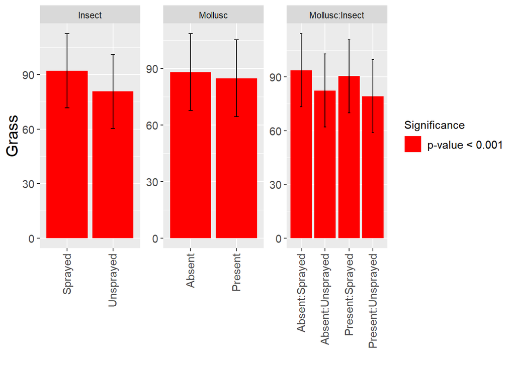

```r
plot(s)
```

LetÂ´s do this for the more complex model

```r
s <- step(as_lmerModLmerTest(m0),reduce.fixed = FALSE, reduce.random = FALSE)
s
```

```
## Backward reduced random-effect table:
##
##                                                          Eliminated npar
## <none>                                                                45
## Insect:Mollusc:Time in (Insect * Mollusc * Time | Block)          0   37
##                                                           logLik    AIC
## <none>                                                   -250.01 590.03
## Insect:Mollusc:Time in (Insect * Mollusc * Time | Block) -249.59 573.18
##                                                               LRT Df
## <none>
## Insect:Mollusc:Time in (Insect * Mollusc * Time | Block) -0.84836  8
##                                                          Pr(>Chisq)
## <none>
## Insect:Mollusc:Time in (Insect * Mollusc * Time | Block)          1
##
## Backward reduced fixed-effect table:
## Degrees of freedom method: Satterthwaite
##
##                     Eliminated Sum Sq Mean Sq NumDF  DenDF F value
## Insect:Mollusc:Time          0 15.776  15.776     1 57.434  7.1502
##                       Pr(>F)
## Insect:Mollusc:Time 0.009744 **
## ---
## Signif. codes:  0 '***' 0.001 '**' 0.01 '*' 0.05 '.' 0.1 ' ' 1
##
## Model found:
## Grass ~ Insect * Mollusc * Time + (Insect * Mollusc * Time |
##     Block)
```

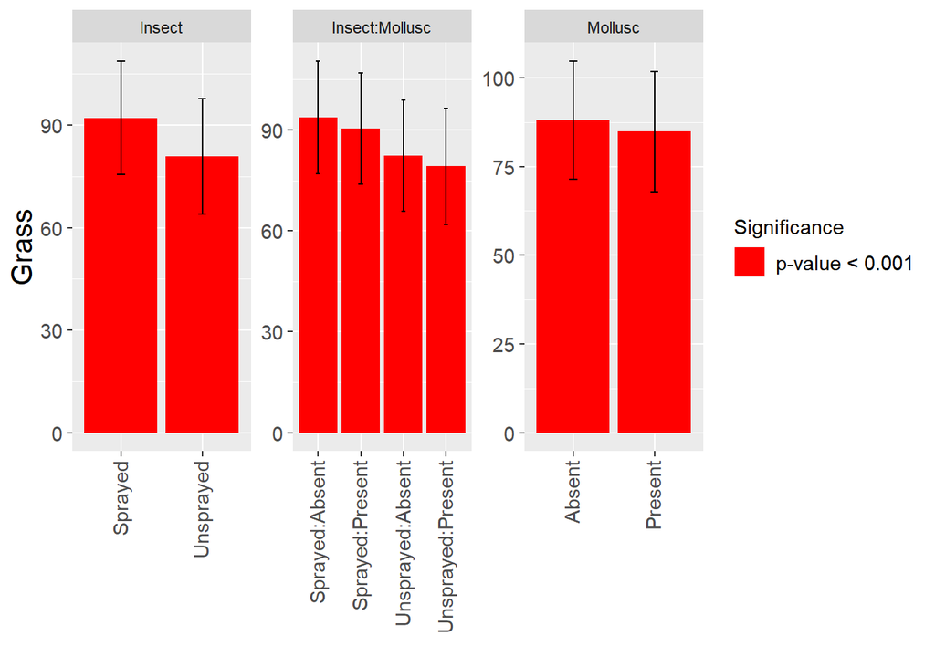

```r
plot(s)
```

More info of this implementation on this

[figure not shown]

### Using RLRsim to do ratio maximum likelihood tests

Exact (Restricted) Likelihood Ratio tests for mixed and additive models.

`exactrLRT` This function provides an (exact) restricted likelihood ratio test based on simulated values from the finite sample distribution for testing whether the variance of a random effect is 0 in a linear mixed model with known correlation structure of the tested random effect and i.i.d. errors.